# Análise de Dados em R - Bloco 3

# Teste de Qui-quadrado

Para executar o teste de qui-quadrado, baixe e carregue o banco de dados “treat_improve.csv” disponível [neste repositório](https://github.com/claudioalvesmonteiro/aulas_analisededados/tree/master/aulas_particulares/dados). No banco constam os casos de um experimento hipotético em que se encontram as informações do grupo de tratamento e o grupo de controle, que recebram uma droga para melhorar desempenho cognitivo e se os indíviduos apresentaram uma melhora ou não após a aplicação da droga.

```r
# visualizar estrutura
str(quiData)
```

```
## Classes 'tbl_df', 'tbl' and 'data.frame':    105 obs. of  3 variables:
##  $ id         : int  1 2 3 4 5 6 7 8 9 10 ...
##  $ treatment  : chr  "treated" "treated" "not-treated" "treated" ...
##  $ improvement: chr  "improved" "improved" "improved" "improved" ...
##  - attr(*, "spec")=List of 2
##   ..$ cols   :List of 3
##   .. ..$ id         : list()
##   .. .. ..- attr(*, "class")= chr  "collector_integer" "collector"
##   .. ..$ treatment  : list()
##   .. .. ..- attr(*, "class")= chr  "collector_character" "collector"
##   .. ..$ improvement: list()
##   .. .. ..- attr(*, "class")= chr  "collector_character" "collector"
##   ..$ default: list()
##   .. ..- attr(*, "class")= chr  "collector_guess" "collector"
##   ..- attr(*, "class")= chr "col_spec"
```

```r
# visualizar contagem dos grupos
table(quiData$treatment, quiData$improvement)
```

```
##
##               improved not-improved
##   not-treated       26           29
##   treated           35           15
```

```r
# executar teste de qui-quadrado
chisq.test(quiData$treatment, quiData$improvement, correct=FALSE)
```

```
##
##  Pearson's Chi-squared test
##
## data:  quiData$treatment and quiData$improvement
## X-squared = 5.5569, df = 1, p-value = 0.01841
```

# Teste T

## Amostras Independente

Importe o banco de dados “Pokemon.csv”, localizado no mesmo repositório, para carregar informacoes sobre os pokémons e executarmos o teste T.

Você viu nas aulas passadas como criar um histograma com o pacote ggplot2. No seu Script execute o código para gerar um gráfico como esse abaixo:

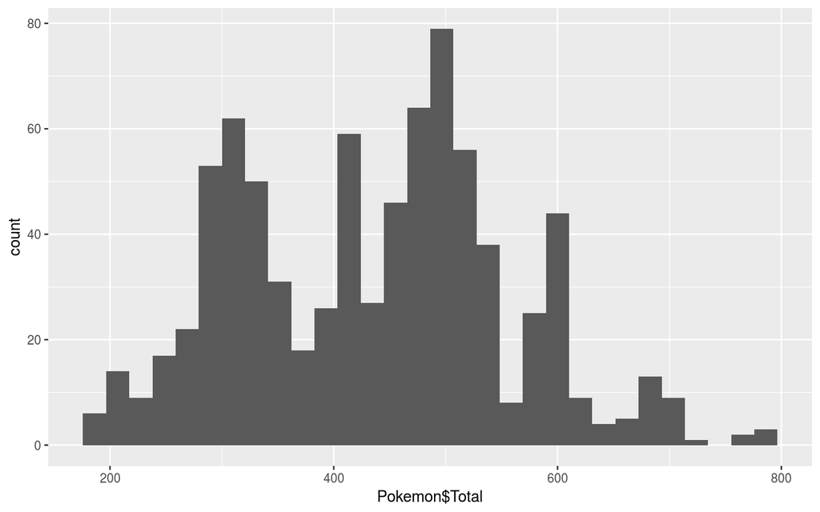

Abaixo segue um gráfico de densidade, que assim como o histograma, mostra a distribuição da variável.

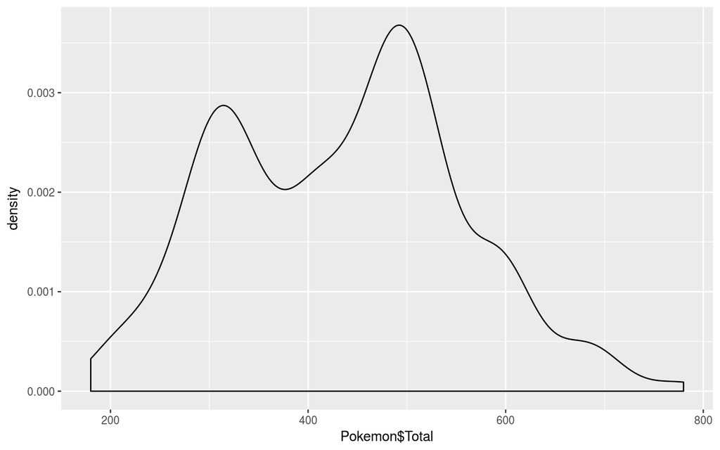

```r
# ggplot densidade
ggplot(data = Pokemon, aes(x = Pokemon$Total))+
  geom_density()
```

```r
# executar teste T
t.test(Pokemon$Total~Pokemon$Legendary)
```

```
##
##  Welch Two Sample t-test
##
## data:  Pokemon$Total by Pokemon$Legendary
## t = -25.834, df = 102.8, p-value < 2.2e-16
## alternative hypothesis: true difference in means is not equal to 0
## 95 percent confidence interval:
##  -237.0741 -203.2679
## sample estimates:
## mean in group False  mean in group True
##            417.2136            637.3846
```

## Amostras Emparelhadas

Para executar o teste T para amostras emparelhadas vamos importar um banco de dados com os pesos de ratos antes e depois de se alimentarem com uma nova ração.

```r
# visualizar estrutura do banco
str(meusRatos)
```

```
## Classes 'tbl_df', 'tbl' and 'data.frame':    20 obs. of  2 variables:
##  $ grupo: chr  "antes" "antes" "antes" "antes" ...
##  $ peso : num  200 191 193 213 241 ...
##  - attr(*, "spec")=List of 2
##   ..$ cols   :List of 2
##   .. ..$ grupo: list()
##   .. .. ..- attr(*, "class")= chr  "collector_character" "collector"
##   .. ..$ peso : list()
##   .. .. ..- attr(*, "class")= chr  "collector_double" "collector"
##   ..$ default: list()
##   .. ..- attr(*, "class")= chr  "collector_guess" "collector"
##   ..- attr(*, "class")= chr "col_spec"
```

```r
# executar teste t para amostras emparelhadas
teste <- t.test(peso ~ grupo, data = meusRatos, paired = TRUE)
teste
```

```
##
##  Paired t-test
##
## data:  peso by grupo
## t = -20.883, df = 9, p-value = 6.2e-09
## alternative hypothesis: true difference in means is not equal to 0
## 95 percent confidence interval:
##  -215.5581 -173.4219
## sample estimates:
## mean of the differences
##                 -194.49
```

# ANOVA

## One Way

Para comparar as médias entre dois grupos ou mais utilizamos o teste ANOVA, nesse temos apenas uma variavel categórica na análise então usamos One Way ANOVA. Para executar este teste vamos utilizar novamente a base de dados de Pokemóns.

Primeiramente vamos visualizar as estatísticas descritivas de cada grupo, dada uma determinada variável, a partir do gráfico de caixa (boxplot):

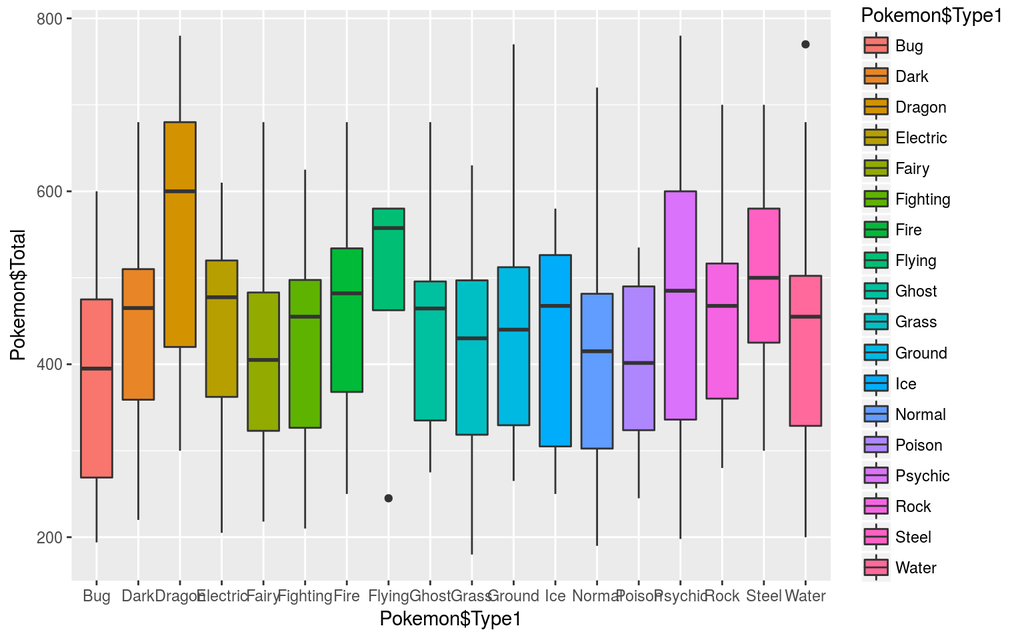

```r
# visualizar boxplot por grupo
ggplot(data = Pokemon, aes(x=Pokemon$Type1, y=Pokemon$Total)) +
  geom_boxplot(aes(fill=Pokemon$Type1))
```

```r
# executar e visualizar modelo ANOVA
fit <- aov(Total ~ Type1, data=Pokemon)
summary(fit)
```

```
##              Df   Sum Sq Mean Sq F value   Pr(>F)
## Type1        17  1053322   61960   4.639 2.08e-09 ***
## Residuals   782 10445192   13357
## ---
## Signif. codes:  0 '***' 0.001 '**' 0.01 '*' 0.05 '.' 0.1 ' ' 1
```

Podemos também executar o teste Tukey Honest Significant Differences para testar diferencas entre cada um dps grupos:

```r
# executar e visualizar o teste Tukey HSD
x <- TukeyHSD(fit, conf.level = 0.95)
x
```

```
##   Tukey multiple comparisons of means
##     95% family-wise confidence level
##
## Fit: aov(formula = Total ~ Type1, data = Pokemon)
##
## $Type1
##                          diff         lwr        upr     p adj
## Dark-Bug            66.814399  -20.660655 154.289454 0.4007122
## Dragon-Bug         171.603714   85.076889 258.130538 0.0000000
## Electric-Bug        64.481555  -13.569352 142.532461 0.2594695
## Fairy-Bug           34.248934  -75.295378 143.793246 0.9998002
## Fighting-Bug        37.516908  -54.320327 129.354144 0.9944203
## Fire-Bug            79.149387    4.854987 153.443787 0.0232609
## Flying-Bug         106.072464 -101.991325 314.136252 0.9476451
## Ghost-Bug           60.634964  -25.891861 147.161788 0.5672890
## Grass-Bug           42.215321  -26.416172 110.846814 0.7836293
## Ground-Bug          58.572464  -27.954361 145.099288 0.6313113
## Ice-Bug             54.530797  -41.343219 150.404813 0.8730386
## Normal-Bug          22.756137  -40.822361  86.334635 0.9988438
## Poison-Bug          20.215321  -70.435537 110.866179 0.9999984
## Psychic-Bug         97.019832   24.607437 169.432227 0.0004560
## Rock-Bug            74.822464   -3.228443 152.873370 0.0780529
## Steel-Bug          108.776167   16.938932 200.613403 0.0048271
## Water-Bug           51.527821  -10.387103 113.442745 0.2475226
## Dragon-Dark        104.789315    2.835366 206.743263 0.0364274
## Electric-Dark       -2.332845  -97.199384  92.533695 1.0000000
## Fairy-Dark         -32.565465 -154.662445  89.531516 0.9999782
## Fighting-Dark      -29.297491 -135.795351  77.200369 0.9999660
## Fire-Dark           12.334988  -79.465744 104.135719 1.0000000
## Flying-Dark         39.258065 -175.679732 254.195861 0.9999999
## Ghost-Dark          -6.179435 -108.133384  95.774513 1.0000000
## Grass-Dark         -24.599078 -111.880223  62.682066 0.9999521
## Ground-Dark         -8.241935 -110.195884  93.712013 1.0000000
## Ice-Dark           -12.283602 -122.281526  97.714322 1.0000000
## Normal-Dark        -44.058262 -127.424573  39.308049 0.9287071
## Poison-Dark        -46.599078 -152.075590  58.877433 0.9868949
## Psychic-Dark        30.205433  -60.078958 120.489824 0.9995106
## Rock-Dark            8.008065  -86.858475 102.874604 1.0000000
## Steel-Dark          41.961768  -64.536092 148.459628 0.9963139
## Water-Dark         -15.286578  -97.391232  66.818075 0.9999999
```

[output cut: 105 more lines]

```
## Poison-Normal       -2.540816  -89.233577  84.151944 1.0000000
## Psychic-Normal      74.263695    6.872215 141.655175 0.0146831
## Rock-Normal         52.066327  -21.350297 125.482950 0.5444962
## Steel-Normal        86.020030   -1.912526 173.952587 0.0634413
## Water-Normal        28.771684  -27.188253  84.731620 0.9436111
## Psychic-Poison      76.804511  -16.560173 170.169195 0.2665347
## Rock-Poison         54.607143  -43.195481 152.409767 0.8894687
## Steel-Poison        88.560847  -20.560586 197.682279 0.2894783
## Water-Poison        31.312500  -54.167715 116.792715 0.9984597
## Rock-Psychic       -22.197368 -103.384376  58.989639 0.9999689
## Steel-Psychic       11.756335  -82.760669 106.273339 1.0000000
## Water-Psychic      -45.492011 -111.316353  20.332331 0.5933510
## Steel-Rock          33.953704  -64.949547 132.856955 0.9993175
## Water-Rock         -23.294643  -95.275425  48.686139 0.9996835
## Water-Steel        -57.248347 -143.985691  29.488998 0.6755781
```

Podemos ainda selecionar apenas as comparacoes que apresentam resultados significativos, a um p-valor menor que 0.05:

```r
datap <- data.frame(x$Type1)
datacomp<-  datap[datap$p.adj < 0.05,]
datacomp
```

```
##                       diff         lwr        upr        p.adj
## Dragon-Bug       171.60371   85.076889 258.130538 0.000000e+00
## Fire-Bug          79.14939    4.854987 153.443787 2.326093e-02
## Psychic-Bug       97.01983   24.607437 169.432227 4.560011e-04
## Steel-Bug        108.77617   16.938932 200.613403 4.827100e-03
## Dragon-Dark      104.78931    2.835366 206.743263 3.642744e-02
## Electric-Dragon -107.12216 -201.115066 -13.129252 8.942786e-03
## Fairy-Dragon    -137.35478 -258.774213 -15.935346 1.001170e-02
## Fighting-Dragon -134.08681 -239.807193 -28.366418 1.406821e-03
## Fire-Dragon      -92.45433 -183.351964  -1.556690 4.120663e-02
## Ghost-Dragon    -110.96875 -212.110304  -9.827196 1.561717e-02
## Grass-Dragon    -129.38839 -215.719178 -43.057608 2.961089e-05
## Ground-Dragon   -113.03125 -214.172804 -11.889696 1.199513e-02
## Ice-Dragon      -117.07292 -226.318281  -7.827553 2.152360e-02
## Normal-Dragon   -148.84758 -231.218372 -66.476781 5.753233e-08
## Poison-Dragon   -151.38839 -256.079847 -46.696938 7.586447e-05
## Rock-Dragon      -96.78125 -190.774157  -2.788343 3.564881e-02
## Water-Dragon    -120.07589 -201.169545 -38.982241 4.101504e-05
## Psychic-Normal    74.26369    6.872215 141.655175 1.468313e-02
```

## Two Way

Para executar o teste Two Way ANOVA vamos trabalhar com o banco hipotético “sheepData.csv”, com dados do sexo, tipo genético e desempenho sexual das ovelhas.

```r
str(ovelhasData)
```

```
## Classes 'tbl_df', 'tbl' and 'data.frame':    36 obs. of  4 variables:
##  $ id             : int  1 2 3 4 5 6 7 8 9 10 ...
##  $ Sex            : chr  "male" "male" "male" "female" ...
##  $ Genotype       : chr  "ff" "ff" "fs" "ff" ...
##  $ Sexual_Activity: num  1.88 2.28 2.4 2.84 2.96 ...
##  - attr(*, "spec")=List of 2
##   ..$ cols   :List of 4
##   .. ..$ id             : list()
##   .. .. ..- attr(*, "class")= chr  "collector_integer" "collector"
##   .. ..$ Sex            : list()
##   .. .. ..- attr(*, "class")= chr  "collector_character" "collector"
##   .. ..$ Genotype       : list()
##   .. .. ..- attr(*, "class")= chr  "collector_character" "collector"
##   .. ..$ Sexual_Activity: list()
##   .. .. ..- attr(*, "class")= chr  "collector_double" "collector"
##   ..$ default: list()
##   .. ..- attr(*, "class")= chr  "collector_guess" "collector"
##   ..- attr(*, "class")= chr "col_spec"
```

```r
# executar e visualizar two way ANOVA
res.aov2 <- aov(Sexual_Activity ~ Sex + Genotype, data = ovelhasData)
summary(res.aov2)
```

```
##             Df Sum Sq Mean Sq F value Pr(>F)
## Sex          1  0.068  0.0681   0.089  0.768
## Genotype     2  0.277  0.1386   0.181  0.835
## Residuals   32 24.528  0.7665
```

# Extra

Um pacote interessante desenvolvido para o R é pacote *viridis* que define algumas paletas de cores mais interessantes para visualização gráfica. Instale e carregue esse pacote para reproduzir o gráfico de múltiplos boxplots.

```r
# carregar pacote
library(viridis)
```

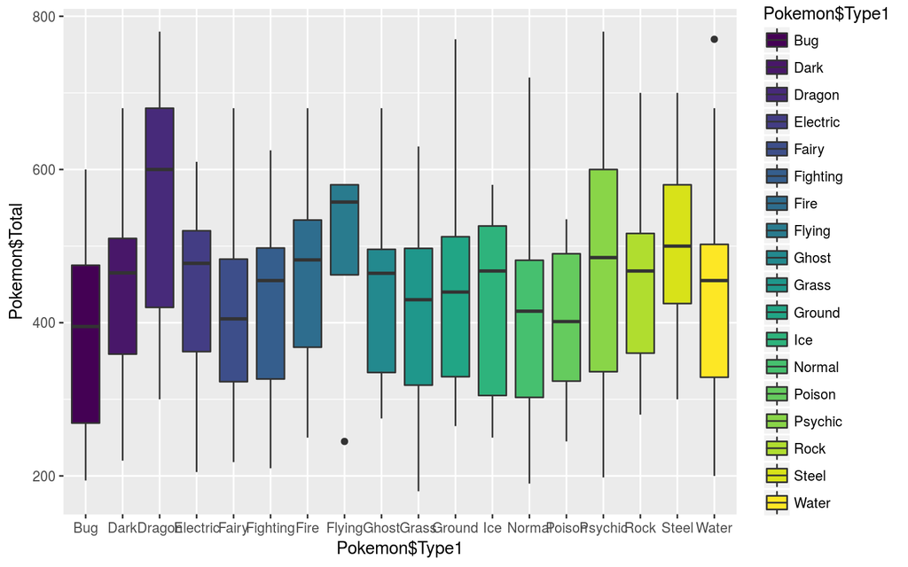

```r
# visualizar boxplot por grupo e definir preechimento com viridis
ggplot(data = Pokemon, aes(x=Pokemon$Type1, y=Pokemon$Total)) +
  geom_boxplot(aes(fill=Pokemon$Type1))+
  scale_fill_viridis(discrete = TRUE)
```

```r
# visualizar documentacao da funcao
?scale_fill_viridis
```

Cláudio A. Monteiro

Maio, 2018